# Functional Enrichment

Carlota Myhre de Gouveia

2026-04-27

# Analysis

## Package Loading

```r
suppressPackageStartupMessages({
  library(tidyverse)
  library(gprofiler2)
  library(clusterProfiler)
  library(enrichplot)
  library(org.Hs.eg.db)
    library(here)
})
```

## Data Import and Tier Definition

```r
# Helper functions

load_tier <- function(path) {
  df <- read_csv(path, show_col_types = FALSE)
  names(df)[1] <- "gene_id"
  distinct(df)
}

extract_gene_id <- function(x) {
  x %>%
    str_remove("\\.p\\d+$") %>%   # remove .p1, .p2
    str_remove("_i\\d+$")         # remove isoform suffix (_i1, _i2)
}


# Load Tier 1 and Tier 2 gene sets

tier1 <- load_tier(
  "results/functional_enrichment/tier1_shared_temperature_response/tier1_shared_temperature_genes.csv"
)

tier2 <- load_tier(
  "results/functional_enrichment/tier2_pop_divergence/tier2_pop_divergence_genes.csv"
)

tier2b <- load_tier(
  "results/functional_enrichment/tier2_pop_divergence/tier2b_local_adaptation/tier2b_local_adaptation_candidates.csv"
)


# Load Tier 3 DE outputs (by temperature)

tier3_mis_12C <- extract_gene_id(
  read_tsv("results/DE/tier3_DE/misexpressed/misexpressed_12C.tsv", col_names = FALSE)$X1
)
tier3_mis_15C <- extract_gene_id(
  read_tsv("results/DE/tier3_DE/misexpressed/misexpressed_15C.tsv", col_names = FALSE)$X1
)
tier3_mis_18C <- extract_gene_id(
  read_tsv("results/DE/tier3_DE/misexpressed/misexpressed_18C.tsv", col_names = FALSE)$X1
)

tier3_parent_S_12C <- extract_gene_id(
  read_tsv("results/DE/tier3_DE/parent_like/parent_like_S_12C.tsv", col_names = FALSE)$X1
)
tier3_parent_S_15C <- extract_gene_id(
  read_tsv("results/DE/tier3_DE/parent_like/parent_like_S_15C.tsv", col_names = FALSE)$X1
)
tier3_parent_S_18C <- extract_gene_id(
  read_tsv("results/DE/tier3_DE/parent_like/parent_like_S_18C.tsv", col_names = FALSE)$X1
)

tier3_parent_W_12C <- extract_gene_id(
  read_tsv("results/DE/tier3_DE/parent_like/parent_like_W_12C.tsv", col_names = FALSE)$X1
)
tier3_parent_W_15C <- extract_gene_id(
  read_tsv("results/DE/tier3_DE/parent_like/parent_like_W_15C.tsv", col_names = FALSE)$X1
)
tier3_parent_W_18C <- extract_gene_id(
  read_tsv("results/DE/tier3_DE/parent_like/parent_like_W_18C.tsv", col_names = FALSE)$X1
)


# Load merged Tier 3 sets

tier3_mis_all <- load_tier(
  "results/functional_enrichment/tier3_hybrid_inheritance/tier3_misexpressed_genes.csv"
)

tier3_parent_S_all <- load_tier(
  "results/functional_enrichment/tier3_hybrid_inheritance/tier3_parent_like_S_genes.csv"
)

tier3_parent_W_all <- load_tier(
  "results/functional_enrichment/tier3_hybrid_inheritance/tier3_parent_like_W_genes.csv"
)


# Load tier intersections

tier1_tier3_mis <- load_tier(
  "results/functional_enrichment/tier_intersections/tier1_tier3_misexpressed.csv"
)

tier1_tier3_parent_S <- load_tier(
  "results/functional_enrichment/tier_intersections/tier1_tier3_parent_like_S.csv"
)

tier1_tier3_parent_W <- load_tier(
  "results/functional_enrichment/tier_intersections/tier1_tier3_parent_like_W.csv"
)

tier2b_tier3_mis <- load_tier(
  "results/functional_enrichment/tier_intersections/tier2b_tier3_misexpressed.csv"
)

tier2b_tier3_parent_S <- load_tier(
  "results/functional_enrichment/tier_intersections/tier2b_tier3_parent_like_S.csv"
)

tier2b_tier3_parent_W <- load_tier(
  "results/functional_enrichment/tier_intersections/tier2b_tier3_parent_like_W.csv"
)


# Define all tiers

tiers <- list(
  "Tier1" = tier1$gene_id,
  "Tier2" = tier2$gene_id,
  "Tier2b" = tier2b$gene_id,

  "Tier3_mis_12C" = tier3_mis_12C,
  "Tier3_mis_15C" = tier3_mis_15C,
  "Tier3_mis_18C" = tier3_mis_18C,

  "Tier3_parent_S_12C" = tier3_parent_S_12C,
  "Tier3_parent_S_15C" = tier3_parent_S_15C,
  "Tier3_parent_S_18C" = tier3_parent_S_18C,

  "Tier3_parent_W_12C" = tier3_parent_W_12C,
  "Tier3_parent_W_15C" = tier3_parent_W_15C,
  "Tier3_parent_W_18C" = tier3_parent_W_18C,

  "Tier3_mis_all" = tier3_mis_all$gene_id,
  "Tier3_parent_S_all" = tier3_parent_S_all$gene_id,
  "Tier3_parent_W_all" = tier3_parent_W_all$gene_id,

  "Tier1∩Tier3_mis" = tier1_tier3_mis$gene_id,
  "Tier1∩Tier3_parent_S" = tier1_tier3_parent_S$gene_id,
  "Tier1∩Tier3_parent_W" = tier1_tier3_parent_W$gene_id,

  "Tier2b∩Tier3_mis" = tier2b_tier3_mis$gene_id,
  "Tier2b∩Tier3_parent_S" = tier2b_tier3_parent_S$gene_id,
  "Tier2b∩Tier3_parent_W" = tier2b_tier3_parent_W$gene_id
)
```

## Load full eggnog annotation

```r
ann <- read.delim(
  "results/annotation/eggnog/Trinity.emapper.annotations",
  comment.char = "#",
  header = FALSE,
  sep = "\t",
  stringsAsFactors = FALSE,
  quote = ""
)

colnames(ann) <- c(
  "query_name", "seed_ortholog", "evalue", "score", "eggNOG_OGs",
  "max_annot_lvl", "COG_category", "Description", "Preferred_name",
  "GOs", "EC", "KEGG_ko", "KEGG_Pathway", "KEGG_Module",
  "KEGG_Reaction", "KEGG_rclass", "BRITE", "KEGG_TC",
  "CAZy", "BiGG_Reaction", "PFAMs"
)
```

## eggNOG annotation overview

```r
# Summary table
eggnog_overview <- tibble(
  Metric = c("Annotated entries", "Annotation fields"),
  Value  = c(nrow(ann), ncol(ann))
)

knitr::kable(
  eggnog_overview,
  caption = "Overview of the eggNOG annotation dataset"
)
```

Overview of the eggNOG annotation dataset

| Metric | Value |
| --- | --- |
| Annotated entries | 206874 |
| Annotation fields | 21 |

```r
# Column names
knitr::kable(
  tibble(Field = colnames(ann)),
  caption = "eggNOG annotation fields"
)
```

eggNOG annotation fields

| Field |
| --- |
| query_name |
| seed_ortholog |
| evalue |
| score |
| eggNOG_OGs |
| max_annot_lvl |
| COG_category |
| Description |
| Preferred_name |
| GOs |
| EC |
| KEGG_ko |
| KEGG_Pathway |
| KEGG_Module |
| KEGG_Reaction |
| KEGG_rclass |
| BRITE |
| KEGG_TC |
| CAZy |
| BiGG_Reaction |
| PFAMs |

```r
# Data preview
knitr::kable(
  head(ann),
  caption = "Preview of the eggNOG annotation table (first 6 rows)"
)
```

Preview of the eggNOG annotation table (first 6 rows)

| query_name | seed_ortholog | evalue | score | eggNOG_OGs | max_annot_lvl | COG_category | Description | Preferred_name | GOs | EC | KEGG_ko | KEGG_Pathway | KEGG_Module | KEGG_Reaction | KEGG_rclass | BRITE | KEGG_TC | CAZy | BiGG_Reaction | PFAMs |
| --- | --- | --- | --- | --- | --- | --- | --- | --- | --- | --- | --- | --- | --- | --- | --- | --- | --- | --- | --- | --- |
| TRINITY_GG_1000_c0_g1_i1.p1 | 8010.XP_010868907.1 | 0 | 127 | 2CMAB@1\|root,2QPSQ@2759\|Eukaryota,39XFZ@33154\|Opisthokonta,3BKCQ@33208\|Metazoa,3D5EX@33213\|Bilateria,48CR0@7711\|Chordata,499IK@7742\|Vertebrata,49XUG@7898\|Actinopterygii | 33208\|Metazoa | T | Odorant receptor, family E, subfamily 120, member 1 | - | - | - | ko:K04257 | ko04740,map04740 | - | - | - | ko00000,ko00001,ko04030 | - | - | - | - |
| TRINITY_GG_1002_c11_g1_i2.p1 | 215358.XP_010730531.1 | 0 | 842 | KOG3626@1\|root,KOG3626@2759\|Eukaryota,38DV9@33154\|Opisthokonta,3BCPB@33208\|Metazoa,3CSZS@33213\|Bilateria,489WX@7711\|Chordata,494EU@7742\|Vertebrata,49QSM@7898\|Actinopterygii | 33208\|Metazoa | Q | Solute carrier organic anion transporter family member | SLCO3A1 | GO:0003674,GO:0005215,GO:0005575,GO:0005623,GO:0005886,GO:0005887,GO:0006810,GO:0006811,GO:0006820,GO:0006857,GO:0006869,GO:0008150,GO:0008509,GO:0008514,GO:0009925,GO:0009986,GO:0010876,GO:0015075,GO… | - | ko:K14353,ko:K14356 | - | - | - | - | ko00000,ko02000 | 2.A.60.1 | - | - | OATP |
| TRINITY_GG_1002_c11_g1_i3.p1 | 215358.XP_010730531.1 | 0 | 755 | KOG3626@1\|root,KOG3626@2759\|Eukaryota,38DV9@33154\|Opisthokonta,3BCPB@33208\|Metazoa,3CSZS@33213\|Bilateria,489WX@7711\|Chordata,494EU@7742\|Vertebrata,49QSM@7898\|Actinopterygii | 33208\|Metazoa | Q | Solute carrier organic anion transporter family member | SLCO3A1 | GO:0003674,GO:0005215,GO:0005575,GO:0005623,GO:0005886,GO:0005887,GO:0006810,GO:0006811,GO:0006820,GO:0006857,GO:0006869,GO:0008150,GO:0008509,GO:0008514,GO:0009925,GO:0009986,GO:0010876,GO:0015075,GO… | - | ko:K14353,ko:K14356 | - | - | - | - | ko00000,ko02000 | 2.A.60.1 | - | - | OATP |
| TRINITY_GG_1002_c11_g1_i4.p1 | 144197.XP_008296061.1 | 0 | 640 | KOG3626@1\|root,KOG3626@2759\|Eukaryota,38DV9@33154\|Opisthokonta,3BCPB@33208\|Metazoa,3CSZS@33213\|Bilateria,489WX@7711\|Chordata,494EU@7742\|Vertebrata,49QSM@7898\|Actinopterygii | 33208\|Metazoa | Q | Solute carrier organic anion transporter family member | SLCO3A1 | GO:0003674,GO:0005215,GO:0005575,GO:0005623,GO:0005886,GO:0005887,GO:0006810,GO:0006811,GO:0006820,GO:0006857,GO:0006869,GO:0008150,GO:0008509,GO:0008514,GO:0009925,GO:0009986,GO:0010876,GO:0015075,GO… | - | ko:K14353,ko:K14356 | - | - | - | - | ko00000,ko02000 | 2.A.60.1 | - | - | OATP |
| TRINITY_GG_1002_c2_g2_i2.p1 | 7955.ENSDARP00000099766 | 0 | 244 | KOG1075@1\|root,KOG1075@2759\|Eukaryota,39N4Q@33154\|Opisthokonta,3B9WN@33208\|Metazoa,3D1S8@33213\|Bilateria,48C1W@7711\|Chordata,49N8J@7742\|Vertebrata,4A94B@7898\|Actinopterygii | 33208\|Metazoa | S | Reverse transcriptase (RNA-dependent DNA polymerase) | - | - | - | - | - | - | - | - | - | - | - | - | RVT_1 |
| TRINITY_GG_1002_c2_g2_i3.p1 | 7955.ENSDARP00000099766 | 0 | 244 | KOG1075@1\|root,KOG1075@2759\|Eukaryota,39N4Q@33154\|Opisthokonta,3B9WN@33208\|Metazoa,3D1S8@33213\|Bilateria,48C1W@7711\|Chordata,49N8J@7742\|Vertebrata,4A94B@7898\|Actinopterygii | 33208\|Metazoa | S | Reverse transcriptase (RNA-dependent DNA polymerase) | - | - | - | - | - | - | - | - | - | - | - | - | RVT_1 |

## Build ortholog mapping (Trinity → Preferred_name)

```r
# Start from annotation table
orth_map <- ann %>%
  dplyr::select(query_name, seed_ortholog, evalue, score, Preferred_name) %>%
  dplyr::filter(Preferred_name != "-" & Preferred_name != "")

# Clean Trinity IDs down to gene_id and keep evalue/score
orth_map_clean <- orth_map %>%
  mutate(
    gene_id = sub("\\.p[0-9]+$", "", query_name),   # remove .p1, .p2
    gene_id = sub("_i[0-9]+$", "", gene_id)         # remove isoform _i1, _i2
  ) %>%
  filter(Preferred_name != "-" & Preferred_name != "") %>%
  distinct(gene_id, Preferred_name, evalue, score)

# Keep ALL valid orthologs per gene (no collapsing to best)
orth_map_all <- orth_map_clean %>%
  distinct(gene_id, Preferred_name, evalue, score)


# Overview table
ortholog_overview <- tibble(
  Metric = c(
    "Ortholog assignments (rows)",
    "Unique Trinity genes",
    "Unique preferred names"
  ),
  Value = c(
    nrow(orth_map_all),
    dplyr::n_distinct(orth_map_all$gene_id),
    dplyr::n_distinct(orth_map_all$Preferred_name)
  )
)


knitr::kable(
  ortholog_overview,
  caption = "Overview of the Trinity–ortholog mapping"
)
```

Overview of the Trinity–ortholog mapping

| Metric | Value |
| --- | --- |
| Ortholog assignments (rows) | 107187 |
| Unique Trinity genes | 24141 |
| Unique preferred names | 14530 |

## Ortholog mapping overview

```r
knitr::kable(
  head(orth_map_all),
  caption = "Preview of the ortholog mapping table (first 6 rows)"
)
```

Preview of the ortholog mapping table (first 6 rows)

| gene_id | Preferred_name | evalue | score |
| --- | --- | --- | --- |
| TRINITY_GG_1002_c11_g1 | SLCO3A1 | 0 | 842 |
| TRINITY_GG_1002_c11_g1 | SLCO3A1 | 0 | 755 |
| TRINITY_GG_1002_c11_g1 | SLCO3A1 | 0 | 640 |
| TRINITY_GG_1002_c3_g1 | PNOC | 0 | 376 |
| TRINITY_GG_1002_c9_g2 | ASTL | 0 | 442 |
| TRINITY_GG_1003_c0_g1 | NLRP12 | 0 | 154 |

## Map tiers to orthologs

```r
# Helper function: map a tier tibble/vector to orthologs
map_to_orthologs <- function(gene_ids, orth_map) {
  orth_map %>%
    filter(gene_id %in% gene_ids) %>%
    pull(Preferred_name) %>%
    unique()
}

# Helper: count how many genes in a set have at least one ortholog
count_mapped_genes <- function(gene_ids, orth_map) {
  mapped <- orth_map %>%
    filter(gene_id %in% gene_ids) %>%
    distinct(gene_id)
  nrow(mapped)
}

# Apply mapping to all tiers using ALL orthologs
tier_orthologs <- lapply(tiers, map_to_orthologs, orth_map = orth_map_all)

# Orthology summary (all orthologs retained)
ortholog_summary <- tibble(
  tier = names(tiers),
  total_genes = sapply(tiers, length),
  genes_with_orthologs = sapply(tiers, count_mapped_genes, orth_map = orth_map_all),
  distinct_orthologs = sapply(tier_orthologs, length)
) %>%
  mutate(
    coverage_pct = round((genes_with_orthologs / total_genes) * 100, 1)
  )
```

```r
knitr::kable(
  ortholog_summary,
  caption = "Summary of ortholog mapping across tiers"
)
```

Summary of ortholog mapping across tiers

| tier | total_genes | genes_with_orthologs | distinct_orthologs | coverage_pct |
| --- | --- | --- | --- | --- |
| Tier1 | 593 | 432 | 481 | 72.8 |
| Tier2 | 1498 | 1001 | 1079 | 66.8 |
| Tier2b | 45 | 26 | 26 | 57.8 |
| Tier3_mis_12C | 277 | 172 | 219 | 62.1 |
| Tier3_mis_15C | 271 | 175 | 211 | 64.6 |
| Tier3_mis_18C | 288 | 197 | 236 | 68.4 |
| Tier3_parent_S_12C | 410 | 257 | 304 | 62.7 |
| Tier3_parent_S_15C | 234 | 153 | 176 | 65.4 |
| Tier3_parent_S_18C | 448 | 316 | 391 | 70.5 |
| Tier3_parent_W_12C | 466 | 283 | 339 | 60.7 |
| Tier3_parent_W_15C | 1259 | 895 | 1067 | 71.1 |
| Tier3_parent_W_18C | 2188 | 1545 | 1841 | 70.6 |
| Tier3_mis_all | 727 | 489 | 589 | 67.3 |
| Tier3_parent_S_all | 936 | 651 | 770 | 69.6 |
| Tier3_parent_W_all | 3067 | 2320 | 2697 | 75.6 |
| Tier1∩Tier3_mis | 23 | 18 | 22 | 78.3 |
| Tier1∩Tier3_parent_S | 37 | 32 | 38 | 86.5 |
| Tier1∩Tier3_parent_W | 146 | 121 | 144 | 82.9 |
| Tier2b∩Tier3_mis | 1 | 1 | 1 | 100.0 |
| Tier2b∩Tier3_parent_S | 3 | 1 | 1 | 33.3 |
| Tier2b∩Tier3_parent_W | 33 | 20 | 20 | 60.6 |

## Run GO enrichment for all tiers

```r
# Classify tiers based on ortholog support
tier_classes <- tibble(
  tier = names(tier_orthologs),
  n_orthologs = sapply(tier_orthologs, length)
) %>%
  mutate(
    enrichment_class = case_when(
      n_orthologs >= 50 ~ "robust",
      n_orthologs >= 15 ~ "grey",
      TRUE              ~ "small"
    )
  )

# Size‑aware GO enrichment function
run_go_enrichment <- function(orthologs, tier_name, tier_class) {

  # Too small → no ORA
  if (tier_class == "small") {
    message(
      "Skipping ", tier_name,
      " (", length(orthologs), " orthologs: too small for ORA)"
    )
    return(NULL)
  }

  # Grey‑zone and robust tiers:
  # use ALL GO domains (BP, MF, CC)
  sources <- c("GO:BP", "GO:MF", "GO:CC")

  gp <- tryCatch(
    gost(
      query = orthologs,
      organism = "hsapiens",
      correction_method = "fdr",
      sources = sources
    ),
    error = function(e) {
      message("g:Profiler failed for ", tier_name)
      return(NULL)
    }
  )

  if (is.null(gp) || is.null(gp$result) || nrow(gp$result) == 0) {
    return(NULL)
  }

  # Attach metadata for interpretation
  gp$result <- gp$result %>%
    mutate(
      tier = tier_name,
      enrichment_class = tier_class,
      n_orthologs_tested = length(orthologs)
    )

  gp
}

# Run enrichment for all tiers, adapting by size class
enrichment_outputs <- lapply(seq_len(nrow(tier_classes)), function(i) {

  tn  <- tier_classes$tier[i]
  cls <- tier_classes$enrichment_class[i]

  run_go_enrichment(
    orthologs = tier_orthologs[[tn]],
    tier_name = tn,
    tier_class = cls
  )
})

names(enrichment_outputs) <- tier_classes$tier
```

## Build GO enrichment summary

```r
enrichment_summary <- tier_classes %>%
  mutate(
    enrichment_run = sapply(
      tier,
      function(tn) !is.null(enrichment_outputs[[tn]])
    ),
    n_terms = sapply(
      tier,
      function(tn) {
        gp <- enrichment_outputs[[tn]]
        if (is.null(gp)) 0 else nrow(gp$result)
      }
    )
  )

knitr::kable(
  enrichment_summary,
  caption = "GO enrichment summary across tiers"
)
```

GO enrichment summary across tiers

| tier | n_orthologs | enrichment_class | enrichment_run | n_terms |
| --- | --- | --- | --- | --- |
| Tier1 | 481 | robust | TRUE | 500 |
| Tier2 | 1079 | robust | TRUE | 574 |
| Tier2b | 26 | grey | TRUE | 2 |
| Tier3_mis_12C | 219 | robust | TRUE | 108 |
| Tier3_mis_15C | 211 | robust | TRUE | 142 |
| Tier3_mis_18C | 236 | robust | TRUE | 65 |
| Tier3_parent_S_12C | 304 | robust | TRUE | 186 |
| Tier3_parent_S_15C | 176 | robust | TRUE | 32 |
| Tier3_parent_S_18C | 391 | robust | TRUE | 168 |
| Tier3_parent_W_12C | 339 | robust | TRUE | 94 |
| Tier3_parent_W_15C | 1067 | robust | TRUE | 654 |
| Tier3_parent_W_18C | 1841 | robust | TRUE | 1422 |
| Tier3_mis_all | 589 | robust | TRUE | 428 |
| Tier3_parent_S_all | 770 | robust | TRUE | 522 |
| Tier3_parent_W_all | 2697 | robust | TRUE | 1769 |
| Tier1∩Tier3_mis | 22 | grey | TRUE | 28 |
| Tier1∩Tier3_parent_S | 38 | grey | TRUE | 39 |
| Tier1∩Tier3_parent_W | 144 | robust | TRUE | 205 |
| Tier2b∩Tier3_mis | 1 | small | FALSE | 0 |
| Tier2b∩Tier3_parent_S | 1 | small | FALSE | 0 |
| Tier2b∩Tier3_parent_W | 20 | grey | TRUE | 10 |

## Build GO enrichment table

```r
# Build GO master table
go_all <- lapply(names(enrichment_outputs), function(tn) {
  gp <- enrichment_outputs[[tn]]

  if (!is.null(gp) && !is.null(gp$result) && nrow(gp$result) > 0) {
    df <- gp$result
    df$tier <- tn
    return(df)
  }

  NULL
}) |> bind_rows()

# Preview across tiers and GO domains
go_all %>%
  dplyr::group_by(tier, source) %>%
  dplyr::slice_head(n = 2) %>%
  dplyr::ungroup() %>%
  dplyr::select(tier, source, term_name, p_value) %>%
  knitr::kable(
    caption = "GO enrichment results (preview across tiers and ontologies)"
  )
```

GO enrichment results (preview across tiers and ontologies)

| tier | source | term_name | p_value |
| --- | --- | --- | --- |
| Tier1 | GO:BP | developmental process | 0.0000000 |
| Tier1 | GO:BP | anatomical structure development | 0.0000000 |
| Tier1 | GO:CC | cytoplasm | 0.0000000 |
| Tier1 | GO:CC | extracellular space | 0.0000000 |
| Tier1 | GO:MF | protein binding | 0.0000001 |
| Tier1 | GO:MF | catalytic activity | 0.0000192 |
| Tier1∩Tier3_mis | GO:BP | homocysteine metabolic process | 0.0253494 |
| Tier1∩Tier3_mis | GO:MF | catalytic activity | 0.0153774 |
| Tier1∩Tier3_mis | GO:MF | cystathionine gamma-lyase activity | 0.0153774 |
| Tier1∩Tier3_parent_S | GO:CC | endoplasmic reticulum lumen | 0.0000553 |
| Tier1∩Tier3_parent_S | GO:CC | extracellular region | 0.0007946 |
| Tier1∩Tier3_parent_S | GO:MF | extracellular matrix structural constituent conferring tensile strength | 0.0002161 |
| Tier1∩Tier3_parent_S | GO:MF | structural constituent of eye lens | 0.0007346 |
| Tier1∩Tier3_parent_W | GO:BP | response to endogenous stimulus | 0.0002189 |
| Tier1∩Tier3_parent_W | GO:BP | anatomical structure development | 0.0002189 |
| Tier1∩Tier3_parent_W | GO:CC | cytoplasm | 0.0000013 |
| Tier1∩Tier3_parent_W | GO:CC | extracellular space | 0.0000108 |
| Tier1∩Tier3_parent_W | GO:MF | extracellular matrix structural constituent | 0.0009460 |
| Tier1∩Tier3_parent_W | GO:MF | isomerase activity | 0.0135215 |
| Tier2 | GO:BP | positive regulation of biological process | 0.0000000 |
| Tier2 | GO:BP | protein metabolic process | 0.0000000 |
| Tier2 | GO:CC | cytoplasm | 0.0000000 |
| Tier2 | GO:CC | cytosol | 0.0000000 |
| Tier2 | GO:MF | protein binding | 0.0000000 |
| Tier2 | GO:MF | enzyme binding | 0.0000000 |
| Tier2b | GO:CC | endoplasmic reticulum | 0.0488537 |
| Tier2b | GO:MF | protein-RNA adaptor activity | 0.0417649 |
| Tier2b∩Tier3_parent_W | GO:MF | protein-RNA adaptor activity | 0.0258623 |
| Tier2b∩Tier3_parent_W | GO:MF | alpha-1,6-mannosyltransferase activity | 0.0492460 |
| Tier3_mis_12C | GO:BP | dense core granule cytoskeletal transport | 0.0031914 |

[output cut: 70 more lines]

## Plot GO enrichment results for all tiers

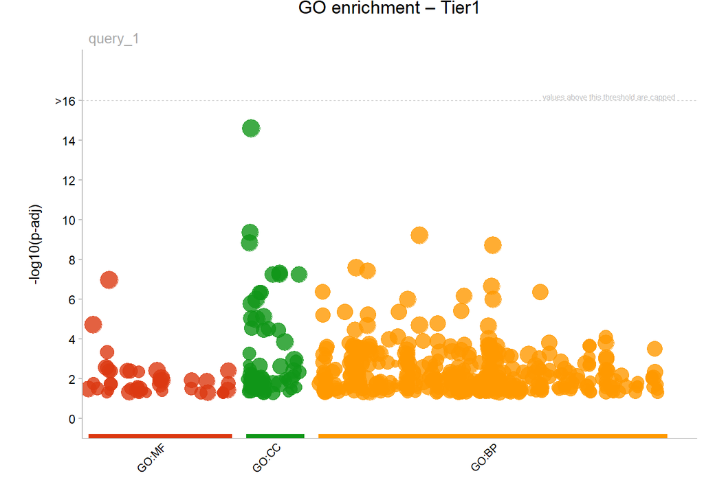

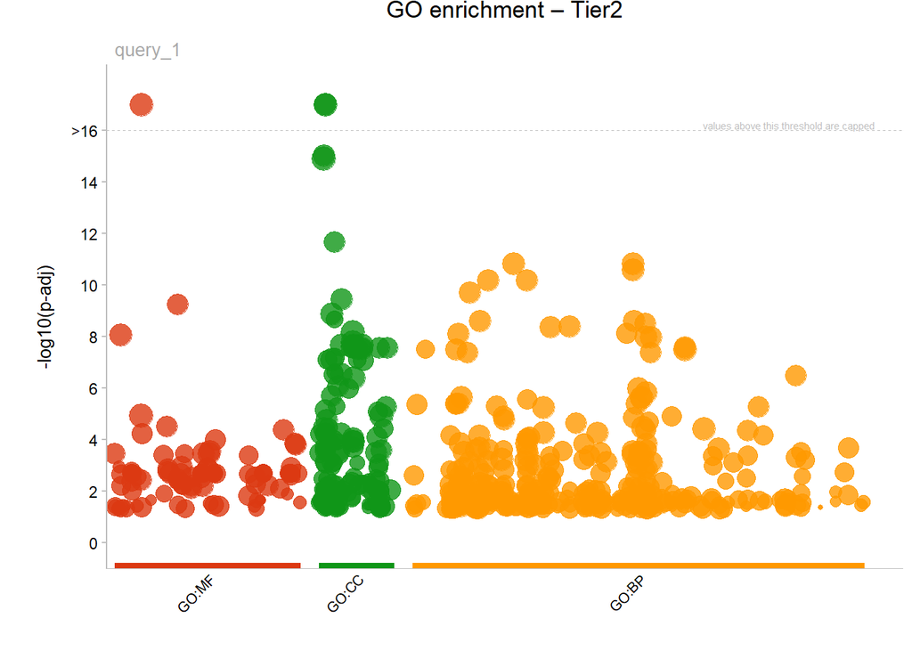

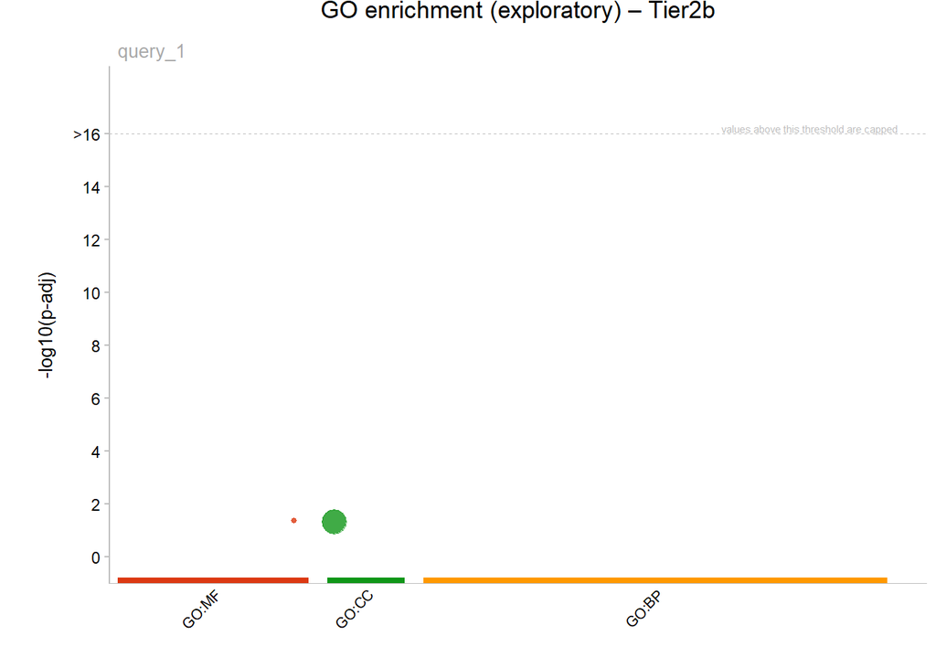

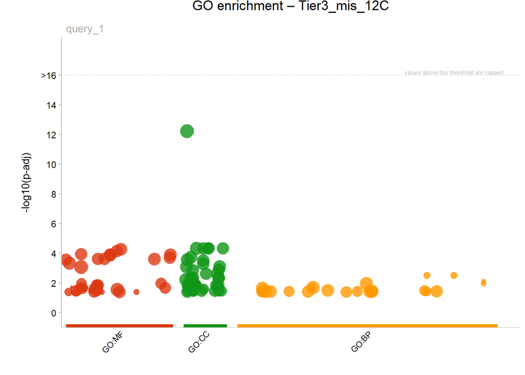

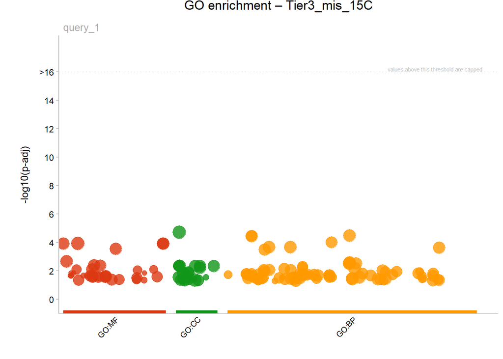

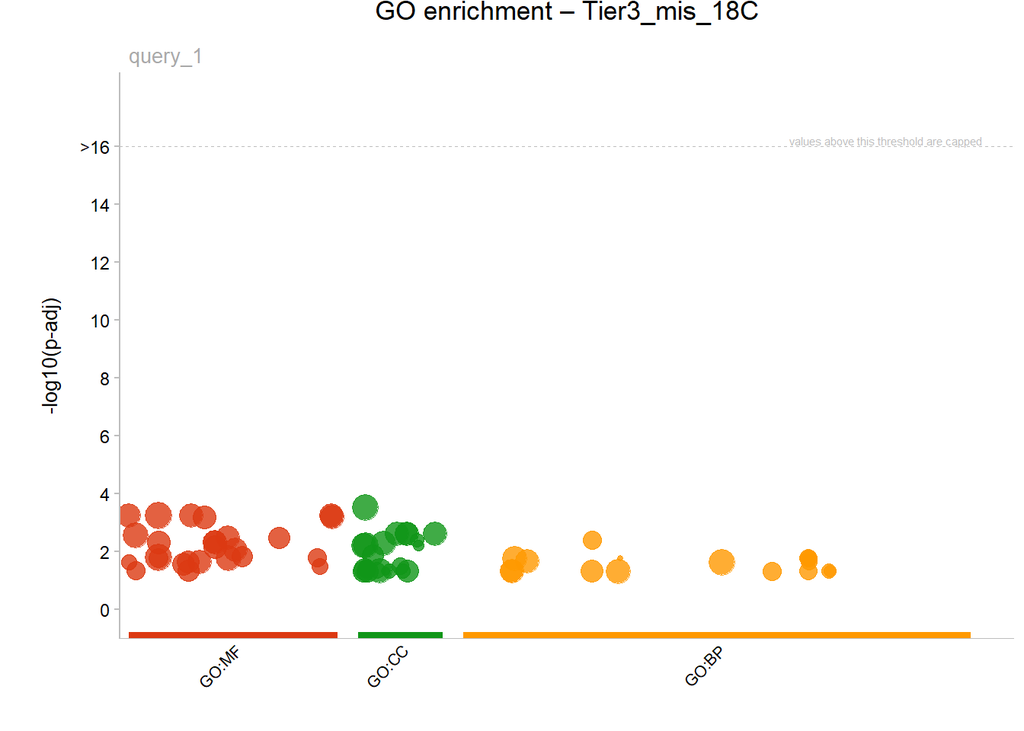

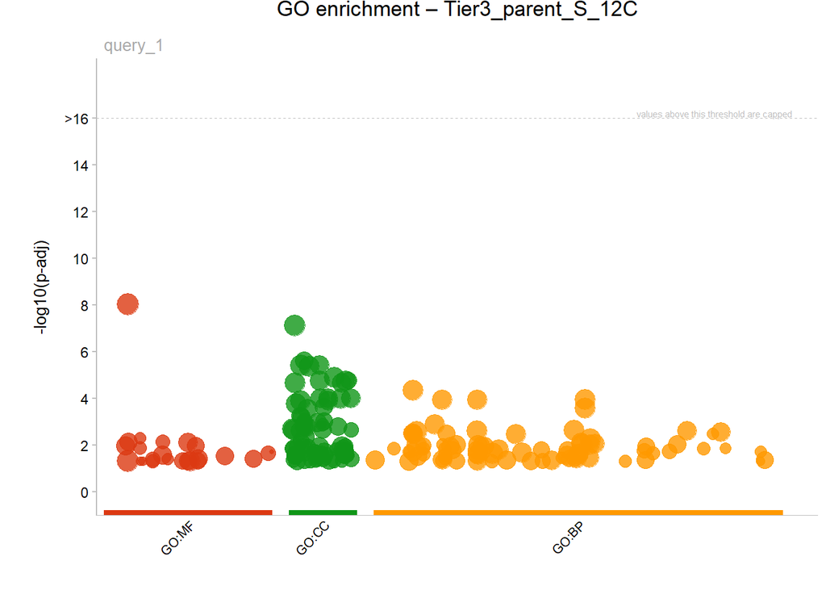

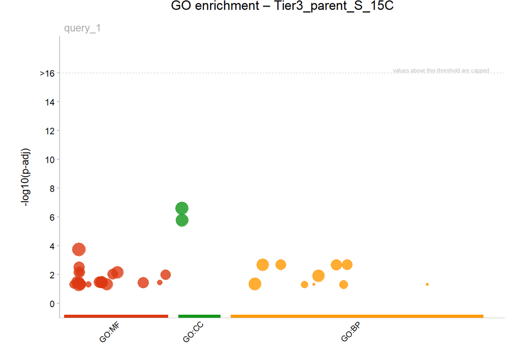

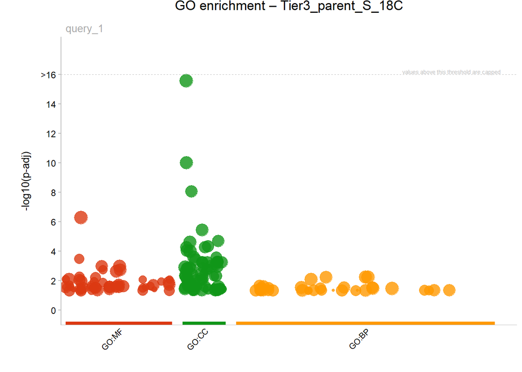

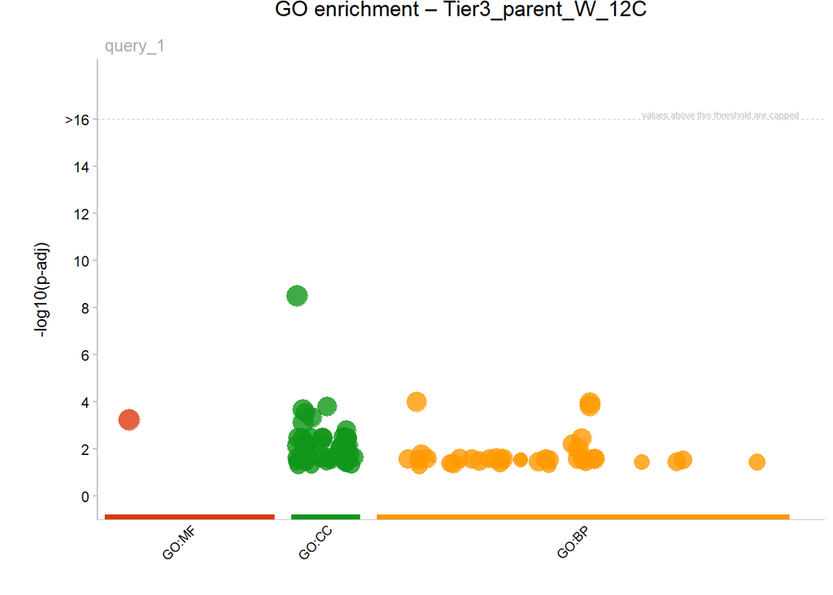

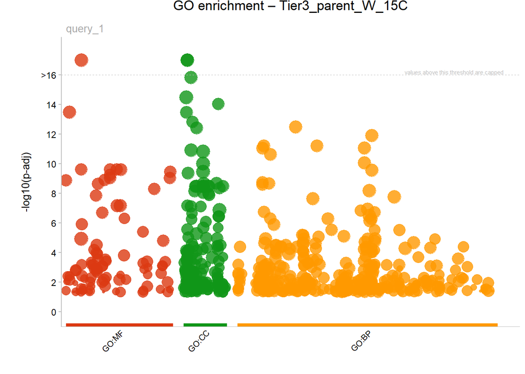

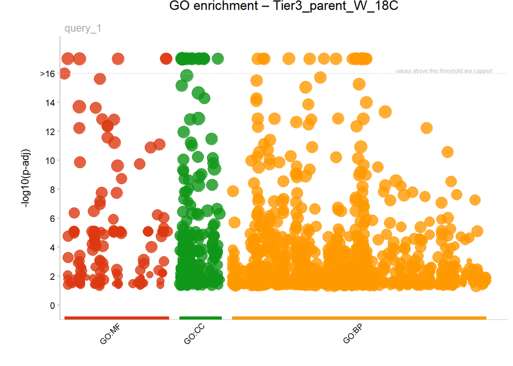

[7 more figures not shown]

```r
for (tn in names(enrichment_outputs)) {

  gp <- enrichment_outputs[[tn]]
  if (is.null(gp)) next

  tier_class <- tier_classes$enrichment_class[
    tier_classes$tier == tn
  ]

  label <- if (tier_class == "grey") {
    paste("GO enrichment (exploratory) –", tn)
  } else {
    paste("GO enrichment –", tn)
  }

  suppressWarnings({
    p <- gostplot(gp, capped = TRUE, interactive = FALSE) +
      ggtitle(label) +
      theme(plot.title = element_text(hjust = 0.5))
    print(p)
  })
}
```

Gene sets derived from Tier 1 and Tier 2b showed contrasting functional enrichment profiles. Tier 1‑based sets consistently exhibited strong GO enrichment together with relatively high ortholog coverage, and retained clear enrichment even in smaller Tier 1‑derived subsets. The higher ortholog coverage in Tier 1 indicates that these genes are more evolutionarily conserved compared to Tier 2b. In contrast, Tier 2b displayed reduced ortholog coverage and limited GO enrichment, indicating greater functional heterogeneity among candidates for population‑specific thermal adaptation. This pattern suggests that Tier 2b is enriched for more lineage‑specific or rapidly evolving genes whose roles are distributed across diverse molecular functions rather than concentrated within a small number of shared biological pathways.

## Dotplots for all tiers

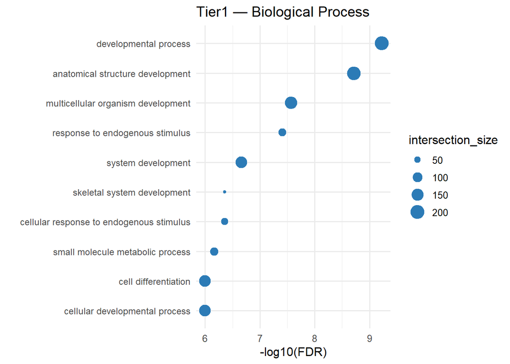

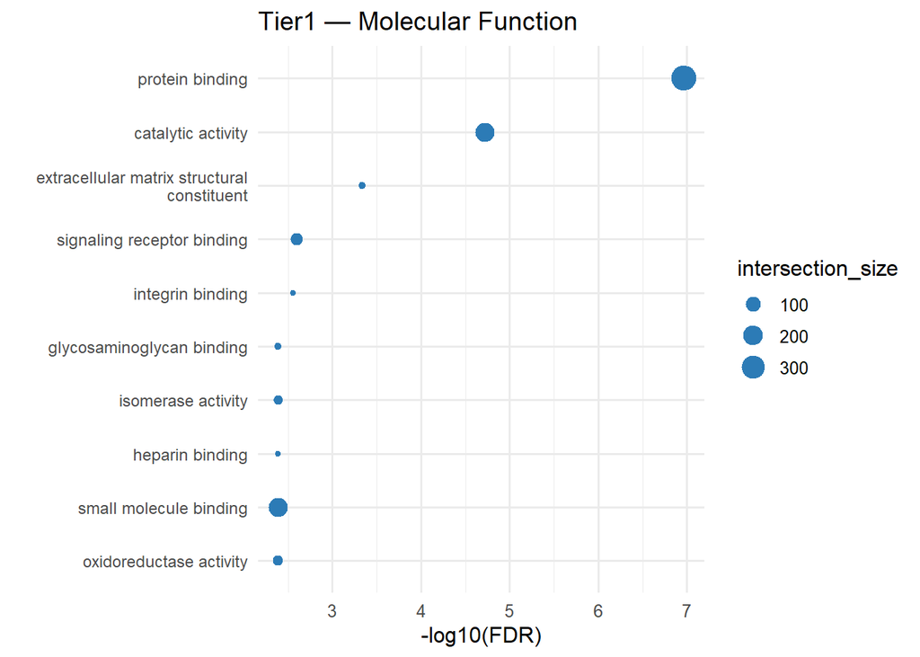

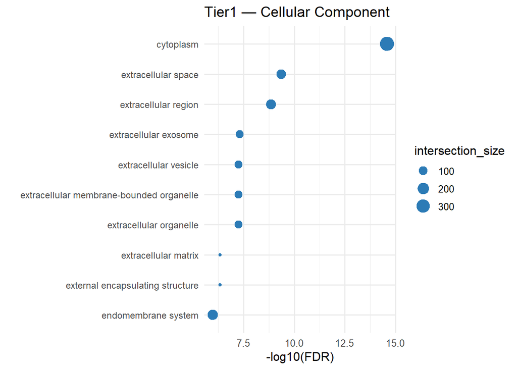

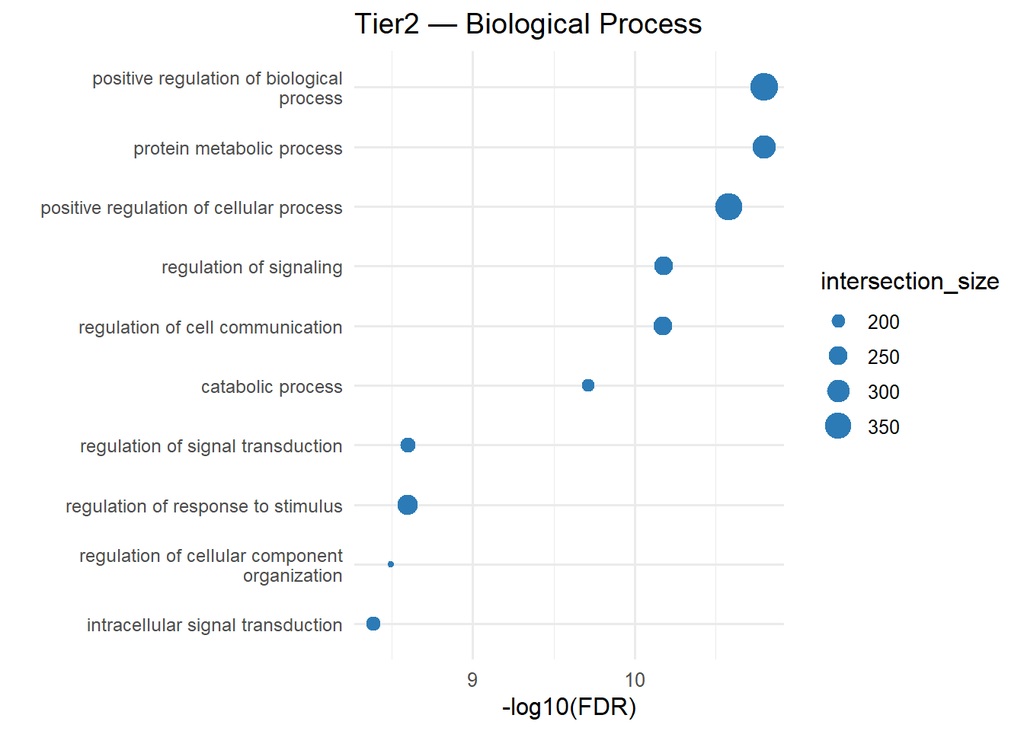

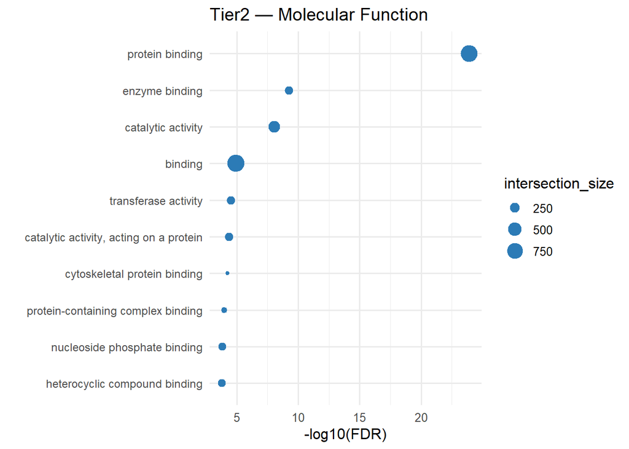

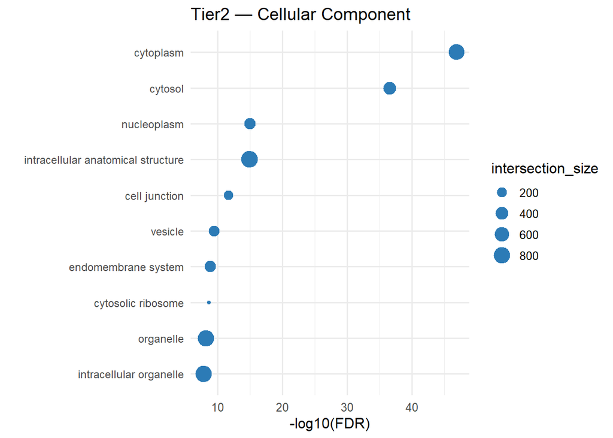

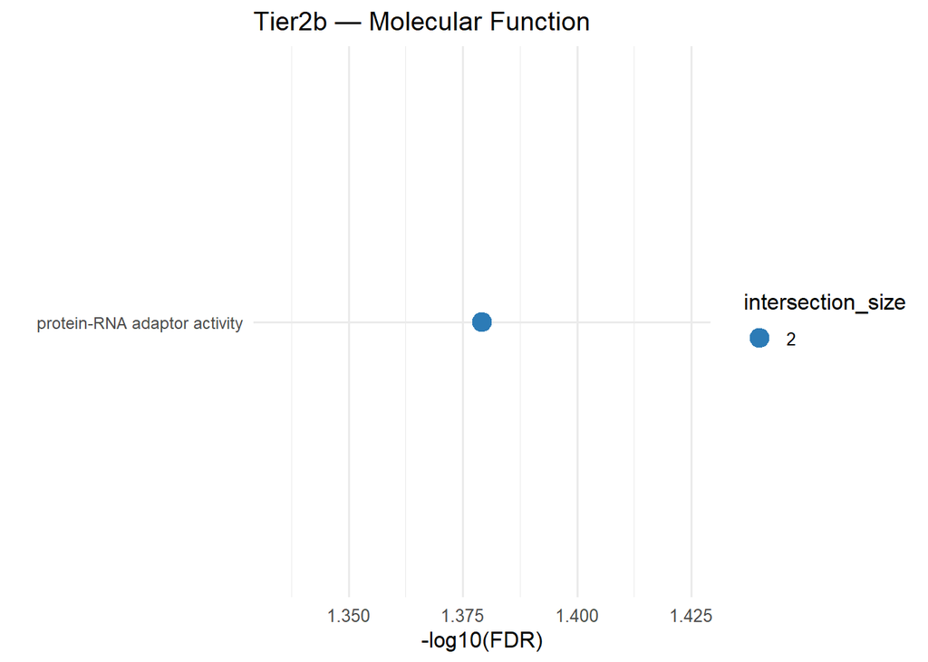

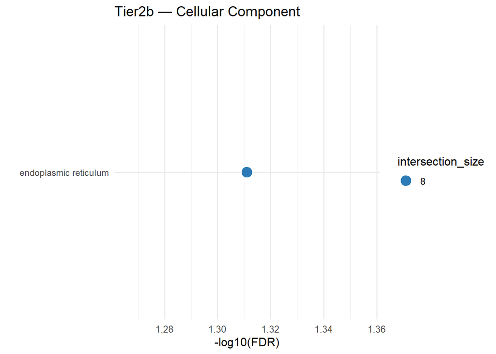

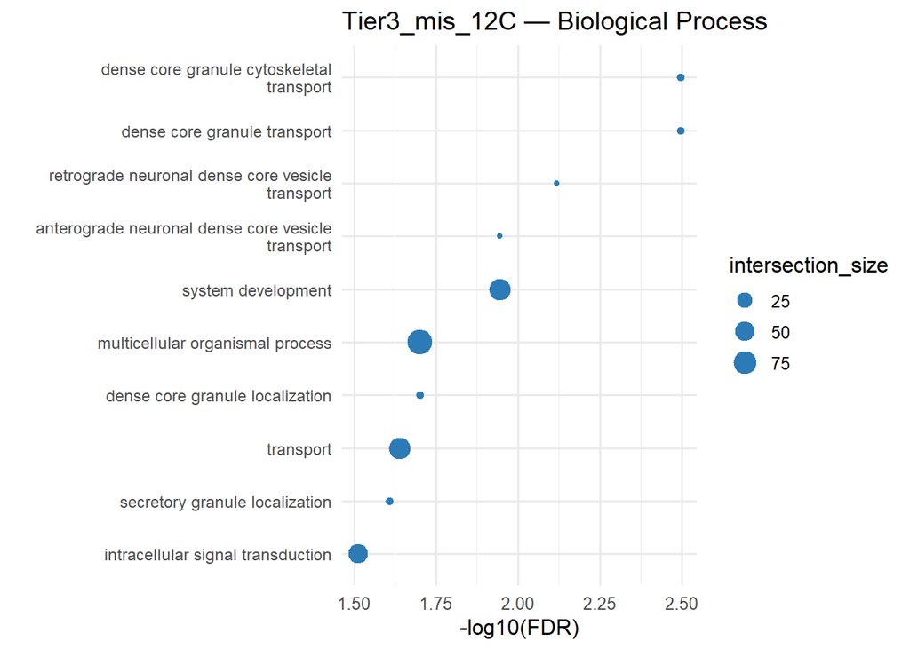

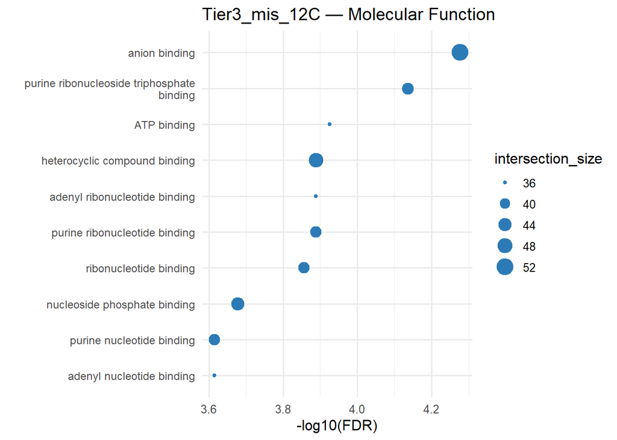

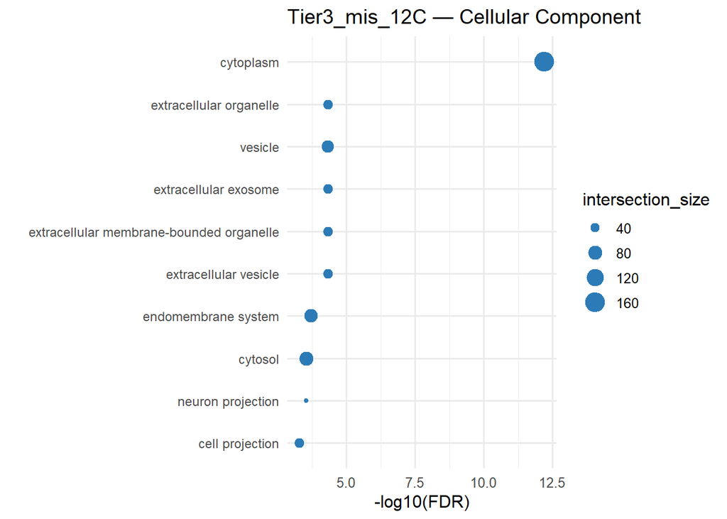

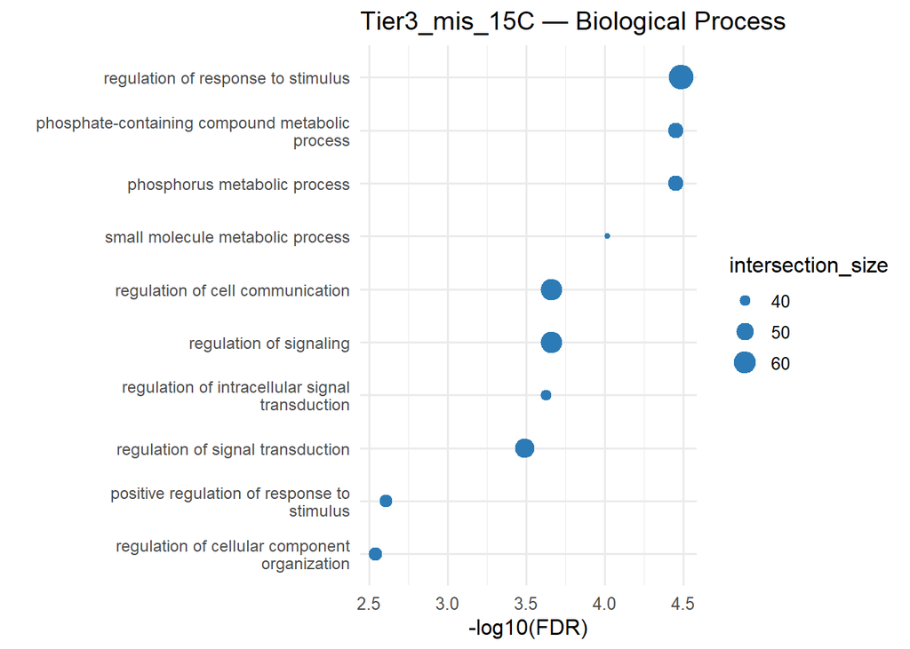

[40 more figures not shown]

```r
go_dotplot <- function(gp_result, tier_class, domain = "GO:BP", n = 10, title = NULL) {

  df <- gp_result %>%
    filter(source == domain) %>%
    arrange(p_value)

  if (nrow(df) == 0) return(NULL)

  # Grey tiers: show all enriched terms
  # Robust tiers: show top n terms
  if (tier_class != "grey") {
    df <- slice_head(df, n = n)
  }

  df <- df %>%
    mutate(
      term_name = str_wrap(term_name, width = 40),
      term_name = factor(term_name, levels = rev(term_name))
    )

  ggplot(df, aes(
    x = -log10(p_value),
    y = term_name,
    size = intersection_size
  )) +
    geom_point(color = "#2C7BB6") +
    labs(
      x = "-log10(FDR)",
      y = "",
      title = title
    ) +
    theme_minimal(base_size = 12) +
    theme(axis.text.y = element_text(size = 9))
}

# Dotplots per tier and GO domain
for (tn in names(enrichment_outputs)) {

  gp <- enrichment_outputs[[tn]]
  if (is.null(gp)) next

  tier_class <- tier_classes$enrichment_class[
    tier_classes$tier == tn
  ]

  df <- gp$result
  if (is.null(df) || nrow(df) == 0) next

  if (any(df$source == "GO:BP")) {
    print(go_dotplot(
      df,
      tier_class = tier_class,
      domain = "GO:BP",
      title = paste(tn, "— Biological Process")
    ))
  }

  if (any(df$source == "GO:MF")) {
    print(go_dotplot(
      df,
      tier_class = tier_class,
      domain = "GO:MF",
      title = paste(tn, "— Molecular Function")
    ))
  }

  if (any(df$source == "GO:CC")) {
    print(go_dotplot(
      df,
      tier_class = tier_class,
      domain = "GO:CC",
      title = paste(tn, "— Cellular Component")
    ))
  }
}
```